# Risk Factor Analysis

## Outcome Variable

**Outcome Variable:** ever_sstunted

## Predictor Variables

**Intervention Variable:** mwtkg

**Adjustment Set:**

- arm
- W_mage
- meducyrs
- feducyrs
- single
- brthmon
- delta_W_mage
- delta_meducyrs
- delta_feducyrs
- delta_single
- delta_brthmon

## Stratifying Variables

The analysis was stratified on these variable(s):

- agecat
- studyid
- country

## Data Summary

| agecat | studyid | country | mwtkg | ever_sstunted | n_cell | n |
| --- | --- | --- | --- | --- | --- | --- |
| 0-24 months | ki0047075b-MAL-ED | BANGLADESH | >=58 kg | 0 | 46 | 254 |
| 0-24 months | ki0047075b-MAL-ED | BANGLADESH | >=58 kg | 1 | 2 | 254 |
| 0-24 months | ki0047075b-MAL-ED | BANGLADESH | <52 kg | 0 | 113 | 254 |
| 0-24 months | ki0047075b-MAL-ED | BANGLADESH | <52 kg | 1 | 49 | 254 |
| 0-24 months | ki0047075b-MAL-ED | BANGLADESH | [52-58) kg | 0 | 40 | 254 |
| 0-24 months | ki0047075b-MAL-ED | BANGLADESH | [52-58) kg | 1 | 4 | 254 |
| 0-24 months | ki0047075b-MAL-ED | BRAZIL | >=58 kg | 0 | 134 | 221 |
| 0-24 months | ki0047075b-MAL-ED | BRAZIL | >=58 kg | 1 | 9 | 221 |
| 0-24 months | ki0047075b-MAL-ED | BRAZIL | <52 kg | 0 | 38 | 221 |
| 0-24 months | ki0047075b-MAL-ED | BRAZIL | <52 kg | 1 | 4 | 221 |
| 0-24 months | ki0047075b-MAL-ED | BRAZIL | [52-58) kg | 0 | 31 | 221 |
| 0-24 months | ki0047075b-MAL-ED | BRAZIL | [52-58) kg | 1 | 5 | 221 |
| 0-24 months | ki0047075b-MAL-ED | INDIA | >=58 kg | 0 | 37 | 242 |
| 0-24 months | ki0047075b-MAL-ED | INDIA | >=58 kg | 1 | 5 | 242 |
| 0-24 months | ki0047075b-MAL-ED | INDIA | <52 kg | 0 | 114 | 242 |
| 0-24 months | ki0047075b-MAL-ED | INDIA | <52 kg | 1 | 36 | 242 |
| 0-24 months | ki0047075b-MAL-ED | INDIA | [52-58) kg | 0 | 36 | 242 |
| 0-24 months | ki0047075b-MAL-ED | INDIA | [52-58) kg | 1 | 14 | 242 |
| 0-24 months | ki0047075b-MAL-ED | NEPAL | >=58 kg | 0 | 75 | 238 |
| 0-24 months | ki0047075b-MAL-ED | NEPAL | >=58 kg | 1 | 5 | 238 |
| 0-24 months | ki0047075b-MAL-ED | NEPAL | <52 kg | 0 | 61 | 238 |
| 0-24 months | ki0047075b-MAL-ED | NEPAL | <52 kg | 1 | 15 | 238 |
| 0-24 months | ki0047075b-MAL-ED | NEPAL | [52-58) kg | 0 | 81 | 238 |
| 0-24 months | ki0047075b-MAL-ED | NEPAL | [52-58) kg | 1 | 1 | 238 |
| 0-24 months | ki0047075b-MAL-ED | PERU | >=58 kg | 0 | 87 | 290 |
| 0-24 months | ki0047075b-MAL-ED | PERU | >=58 kg | 1 | 17 | 290 |
| 0-24 months | ki0047075b-MAL-ED | PERU | <52 kg | 0 | 87 | 290 |
| 0-24 months | ki0047075b-MAL-ED | PERU | <52 kg | 1 | 28 | 290 |
| 0-24 months | ki0047075b-MAL-ED | PERU | [52-58) kg | 0 | 53 | 290 |
| 0-24 months | ki0047075b-MAL-ED | PERU | [52-58) kg | 1 | 18 | 290 |

[output cut: 156 more lines]

The following strata were considered:

- agecat: 0-24 months, studyid: ki0047075b-MAL-ED, country: BANGLADESH
- agecat: 0-24 months, studyid: ki0047075b-MAL-ED, country: BRAZIL
- agecat: 0-24 months, studyid: ki0047075b-MAL-ED, country: INDIA
- agecat: 0-24 months, studyid: ki0047075b-MAL-ED, country: NEPAL
- agecat: 0-24 months, studyid: ki0047075b-MAL-ED, country: PERU
- agecat: 0-24 months, studyid: ki0047075b-MAL-ED, country: SOUTH AFRICA
- agecat: 0-24 months, studyid: ki0047075b-MAL-ED, country: TANZANIA, UNITED REPUBLIC OF
- agecat: 0-24 months, studyid: ki1000304b-SAS-CompFeed, country: INDIA
- agecat: 0-24 months, studyid: ki1017093-NIH-Birth, country: BANGLADESH
- agecat: 0-24 months, studyid: ki1017093b-PROVIDE, country: BANGLADESH
- agecat: 0-24 months, studyid: ki1017093c-NIH-Crypto, country: BANGLADESH
- agecat: 0-24 months, studyid: ki1066203-TanzaniaChild2, country: TANZANIA, UNITED REPUBLIC OF
- agecat: 0-24 months, studyid: ki1112895-iLiNS-Zinc, country: BURKINA FASO
- agecat: 0-24 months, studyid: ki1119695-PROBIT, country: BELARUS
- agecat: 0-24 months, studyid: ki1126311-ZVITAMBO, country: ZIMBABWE
- agecat: 0-24 months, studyid: ki1148112-LCNI-5, country: MALAWI
- agecat: 0-6 months, studyid: ki0047075b-MAL-ED, country: BANGLADESH
- agecat: 0-6 months, studyid: ki0047075b-MAL-ED, country: BRAZIL
- agecat: 0-6 months, studyid: ki0047075b-MAL-ED, country: INDIA
- agecat: 0-6 months, studyid: ki0047075b-MAL-ED, country: NEPAL
- agecat: 0-6 months, studyid: ki0047075b-MAL-ED, country: PERU
- agecat: 0-6 months, studyid: ki0047075b-MAL-ED, country: SOUTH AFRICA
- agecat: 0-6 months, studyid: ki0047075b-MAL-ED, country: TANZANIA, UNITED REPUBLIC OF
- agecat: 0-6 months, studyid: ki1000304b-SAS-CompFeed, country: INDIA
- agecat: 0-6 months, studyid: ki1017093-NIH-Birth, country: BANGLADESH
- agecat: 0-6 months, studyid: ki1017093b-PROVIDE, country: BANGLADESH
- agecat: 0-6 months, studyid: ki1017093c-NIH-Crypto, country: BANGLADESH
- agecat: 0-6 months, studyid: ki1066203-TanzaniaChild2, country: TANZANIA, UNITED REPUBLIC OF
- agecat: 0-6 months, studyid: ki1119695-PROBIT, country: BELARUS
- agecat: 0-6 months, studyid: ki1126311-ZVITAMBO, country: ZIMBABWE
- agecat: 0-6 months, studyid: ki1148112-LCNI-5, country: MALAWI

### Dropped Strata

Some strata were dropped due to rare outcomes:

- agecat: 0-24 months, studyid: ki0047075b-MAL-ED, country: BANGLADESH
- agecat: 0-24 months, studyid: ki0047075b-MAL-ED, country: BRAZIL
- agecat: 0-24 months, studyid: ki0047075b-MAL-ED, country: NEPAL
- agecat: 0-6 months, studyid: ki0047075b-MAL-ED, country: BANGLADESH
- agecat: 0-6 months, studyid: ki0047075b-MAL-ED, country: BRAZIL
- agecat: 0-6 months, studyid: ki0047075b-MAL-ED, country: INDIA
- agecat: 0-6 months, studyid: ki0047075b-MAL-ED, country: NEPAL
- agecat: 0-6 months, studyid: ki0047075b-MAL-ED, country: SOUTH AFRICA
- agecat: 0-6 months, studyid: ki1000304b-SAS-CompFeed, country: INDIA
- agecat: 0-6 months, studyid: ki1017093b-PROVIDE, country: BANGLADESH
- agecat: 0-6 months, studyid: ki1148112-LCNI-5, country: MALAWI

## Methods Detail

We’re interested in the causal parameters $E[Y_a]$ for all values of $a \in \mathcal{A}$. These parameters represent the mean outcome if, possibly contrary to fact, we intervened to set all units to have $A=a$. Under the randomization and positivity assumptions, these are identified by the statistical parameters $\psi_a=E_W[E_{Y|A,W}(Y|A=a,W)]$. In addition, we’re interested in the mean of $Y$, $E[Y]$ under no intervention (the observed mean). We will estimate these parameters by using SuperLearner to fit the relevant likelihood factors – $E_{Y|A,W}(Y|A=a,W)$ and $p(A=a|W)$, and then updating our likelihood fit using a joint TMLE.

For unadjusted analyses ($W=\{\}$), initial likelihoods were estimated using Lrnr_glm to estimate the simple $E(Y|A)$ and Lrnr_mean to estimate $p(A)$. For adjusted analyses, a small library containing Lrnr_glmnet, Lrnr_xgboost, and Lrnr_mean was used.

Having estimated these parameters, we will then use the delta method to estimate relative risks and attributable risks relative to a prespecified baseline level of $A$.

# Results Detail

## Results Plots

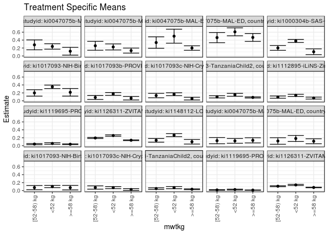

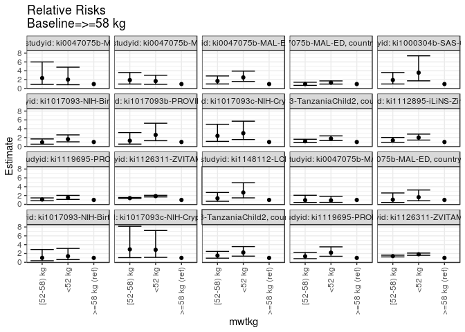

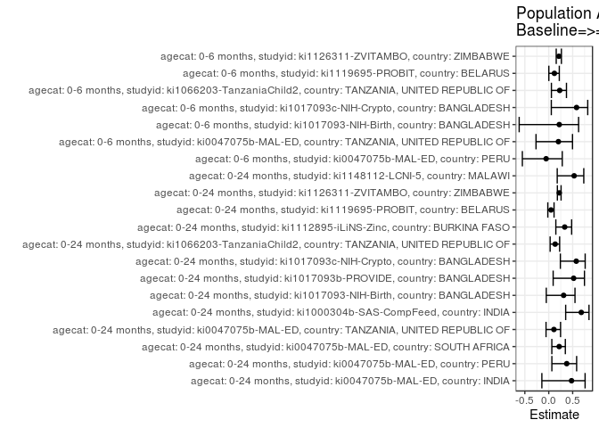

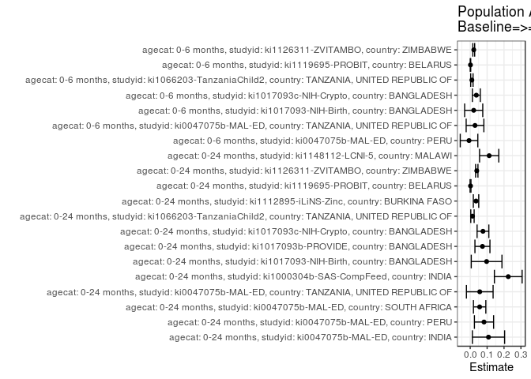

## Results Table

### Parameter: TSM

| agecat | studyid | country | intervention_level | baseline_level | estimate | ci_lower | ci_upper |
| --- | --- | --- | --- | --- | --- | --- | --- |
| 0-24 months | ki0047075b-MAL-ED | INDIA | >=58 kg | NA | 0.1190476 | 0.0209047 | 0.2171906 |
| 0-24 months | ki0047075b-MAL-ED | INDIA | <52 kg | NA | 0.2400000 | 0.1715121 | 0.3084879 |
| 0-24 months | ki0047075b-MAL-ED | INDIA | [52-58) kg | NA | 0.2800000 | 0.1552882 | 0.4047118 |
| 0-24 months | ki0047075b-MAL-ED | PERU | >=58 kg | NA | 0.1356299 | 0.0720732 | 0.1991865 |
| 0-24 months | ki0047075b-MAL-ED | PERU | <52 kg | NA | 0.2272835 | 0.1510294 | 0.3035376 |
| 0-24 months | ki0047075b-MAL-ED | PERU | [52-58) kg | NA | 0.2572116 | 0.1442663 | 0.3701568 |
| 0-24 months | ki0047075b-MAL-ED | SOUTH AFRICA | >=58 kg | NA | 0.1997840 | 0.1429669 | 0.2566010 |
| 0-24 months | ki0047075b-MAL-ED | SOUTH AFRICA | <52 kg | NA | 0.4987815 | 0.3221939 | 0.6753691 |
| 0-24 months | ki0047075b-MAL-ED | SOUTH AFRICA | [52-58) kg | NA | 0.3383513 | 0.1940255 | 0.4826770 |
| 0-24 months | ki0047075b-MAL-ED | TANZANIA, UNITED REPUBLIC OF | >=58 kg | NA | 0.4669638 | 0.3674687 | 0.5664588 |
| 0-24 months | ki0047075b-MAL-ED | TANZANIA, UNITED REPUBLIC OF | <52 kg | NA | 0.6084625 | 0.5081632 | 0.7087619 |
| 0-24 months | ki0047075b-MAL-ED | TANZANIA, UNITED REPUBLIC OF | [52-58) kg | NA | 0.4631461 | 0.3345815 | 0.5917107 |
| 0-24 months | ki1000304b-SAS-CompFeed | INDIA | >=58 kg | NA | 0.1058933 | 0.0335505 | 0.1782361 |
| 0-24 months | ki1000304b-SAS-CompFeed | INDIA | <52 kg | NA | 0.3781920 | 0.3393520 | 0.4170319 |
| 0-24 months | ki1000304b-SAS-CompFeed | INDIA | [52-58) kg | NA | 0.2022986 | 0.1421686 | 0.2624286 |
| 0-24 months | ki1017093-NIH-Birth | BANGLADESH | >=58 kg | NA | 0.2146687 | 0.1191000 | 0.3102374 |
| 0-24 months | ki1017093-NIH-Birth | BANGLADESH | <52 kg | NA | 0.3529378 | 0.3086808 | 0.3971949 |
| 0-24 months | ki1017093-NIH-Birth | BANGLADESH | [52-58) kg | NA | 0.1990873 | 0.1184960 | 0.2796786 |
| 0-24 months | ki1017093b-PROVIDE | BANGLADESH | >=58 kg | NA | 0.0666667 | 0.0220029 | 0.1113304 |
| 0-24 months | ki1017093b-PROVIDE | BANGLADESH | <52 kg | NA | 0.1736111 | 0.1378664 | 0.2093558 |
| 0-24 months | ki1017093b-PROVIDE | BANGLADESH | [52-58) kg | NA | 0.0854701 | 0.0347726 | 0.1361675 |
| 0-24 months | ki1017093c-NIH-Crypto | BANGLADESH | >=58 kg | NA | 0.0556922 | 0.0217038 | 0.0896806 |
| 0-24 months | ki1017093c-NIH-Crypto | BANGLADESH | <52 kg | NA | 0.1662991 | 0.1298164 | 0.2027819 |
| 0-24 months | ki1017093c-NIH-Crypto | BANGLADESH | [52-58) kg | NA | 0.1331086 | 0.0770185 | 0.1891988 |
| 0-24 months | ki1066203-TanzaniaChild2 | TANZANIA, UNITED REPUBLIC OF | >=58 kg | NA | 0.0857989 | 0.0713425 | 0.1002553 |
| 0-24 months | ki1066203-TanzaniaChild2 | TANZANIA, UNITED REPUBLIC OF | <52 kg | NA | 0.1521481 | 0.1154352 | 0.1888610 |
| 0-24 months | ki1066203-TanzaniaChild2 | TANZANIA, UNITED REPUBLIC OF | [52-58) kg | NA | 0.1004967 | 0.0727087 | 0.1282847 |
| 0-24 months | ki1112895-iLiNS-Zinc | BURKINA FASO | >=58 kg | NA | 0.0688091 | 0.0441760 | 0.0934422 |
| 0-24 months | ki1112895-iLiNS-Zinc | BURKINA FASO | <52 kg | NA | 0.1376704 | 0.1106557 | 0.1646852 |
| 0-24 months | ki1112895-iLiNS-Zinc | BURKINA FASO | [52-58) kg | NA | 0.0942582 | 0.0652615 | 0.1232550 |
| 0-24 months | ki1119695-PROBIT | BELARUS | >=58 kg | NA | 0.0369909 | 0.0286839 | 0.0452980 |
| 0-24 months | ki1119695-PROBIT | BELARUS | <52 kg | NA | 0.0558097 | 0.0362184 | 0.0754009 |
| 0-24 months | ki1119695-PROBIT | BELARUS | [52-58) kg | NA | 0.0405391 | 0.0266953 | 0.0543830 |
| 0-24 months | ki1126311-ZVITAMBO | ZIMBABWE | >=58 kg | NA | 0.1374996 | 0.1285776 | 0.1464217 |
| 0-24 months | ki1126311-ZVITAMBO | ZIMBABWE | <52 kg | NA | 0.2559475 | 0.2380021 | 0.2738930 |
| 0-24 months | ki1126311-ZVITAMBO | ZIMBABWE | [52-58) kg | NA | 0.1943372 | 0.1796985 | 0.2089758 |
| 0-24 months | ki1148112-LCNI-5 | MALAWI | >=58 kg | NA | 0.0991113 | 0.0412898 | 0.1569329 |
| 0-24 months | ki1148112-LCNI-5 | MALAWI | <52 kg | NA | 0.2661155 | 0.2275137 | 0.3047174 |
| 0-24 months | ki1148112-LCNI-5 | MALAWI | [52-58) kg | NA | 0.1354563 | 0.0891503 | 0.1817622 |
| 0-6 months | ki0047075b-MAL-ED | PERU | >=58 kg | NA | 0.1346154 | 0.0689051 | 0.2003257 |
| 0-6 months | ki0047075b-MAL-ED | PERU | <52 kg | NA | 0.1217391 | 0.0618737 | 0.1816046 |
| 0-6 months | ki0047075b-MAL-ED | PERU | [52-58) kg | NA | 0.1267606 | 0.0492381 | 0.2042831 |
| 0-6 months | ki0047075b-MAL-ED | TANZANIA, UNITED REPUBLIC OF | >=58 kg | NA | 0.1122449 | 0.0496246 | 0.1748652 |
| 0-6 months | ki0047075b-MAL-ED | TANZANIA, UNITED REPUBLIC OF | <52 kg | NA | 0.1818182 | 0.1056938 | 0.2579426 |
| 0-6 months | ki0047075b-MAL-ED | TANZANIA, UNITED REPUBLIC OF | [52-58) kg | NA | 0.1186441 | 0.0359697 | 0.2013184 |
| 0-6 months | ki1017093-NIH-Birth | BANGLADESH | >=58 kg | NA | 0.0731707 | 0.0167608 | 0.1295806 |
| 0-6 months | ki1017093-NIH-Birth | BANGLADESH | <52 kg | NA | 0.1015453 | 0.0737083 | 0.1293823 |
| 0-6 months | ki1017093-NIH-Birth | BANGLADESH | [52-58) kg | NA | 0.0744681 | 0.0213539 | 0.1275823 |
| 0-6 months | ki1017093c-NIH-Crypto | BANGLADESH | >=58 kg | NA | 0.0260417 | 0.0034998 | 0.0485835 |
| 0-6 months | ki1017093c-NIH-Crypto | BANGLADESH | <52 kg | NA | 0.0738916 | 0.0484291 | 0.0993541 |
| 0-6 months | ki1017093c-NIH-Crypto | BANGLADESH | [52-58) kg | NA | 0.0764331 | 0.0348458 | 0.1180205 |
| 0-6 months | ki1066203-TanzaniaChild2 | TANZANIA, UNITED REPUBLIC OF | >=58 kg | NA | 0.0331124 | 0.0238533 | 0.0423714 |
| 0-6 months | ki1066203-TanzaniaChild2 | TANZANIA, UNITED REPUBLIC OF | <52 kg | NA | 0.0737631 | 0.0462058 | 0.1013205 |
| 0-6 months | ki1066203-TanzaniaChild2 | TANZANIA, UNITED REPUBLIC OF | [52-58) kg | NA | 0.0505162 | 0.0304960 | 0.0705364 |
| 0-6 months | ki1119695-PROBIT | BELARUS | >=58 kg | NA | 0.0114655 | 0.0080048 | 0.0149262 |
| 0-6 months | ki1119695-PROBIT | BELARUS | <52 kg | NA | 0.0251180 | 0.0141051 | 0.0361309 |
| 0-6 months | ki1119695-PROBIT | BELARUS | [52-58) kg | NA | 0.0155122 | 0.0066522 | 0.0243722 |
| 0-6 months | ki1126311-ZVITAMBO | ZIMBABWE | >=58 kg | NA | 0.0778042 | 0.0708466 | 0.0847618 |
| 0-6 months | ki1126311-ZVITAMBO | ZIMBABWE | <52 kg | NA | 0.1419796 | 0.1276382 | 0.1563210 |
| 0-6 months | ki1126311-ZVITAMBO | ZIMBABWE | [52-58) kg | NA | 0.1093391 | 0.0976023 | 0.1210760 |

### Parameter: E(Y)

| agecat | studyid | country | intervention_level | baseline_level | estimate | ci_lower | ci_upper |
| --- | --- | --- | --- | --- | --- | --- | --- |
| 0-24 months | ki0047075b-MAL-ED | INDIA | NA | NA | 0.2272727 | 0.1743641 | 0.2801813 |
| 0-24 months | ki0047075b-MAL-ED | PERU | NA | NA | 0.2172414 | 0.1696986 | 0.2647841 |
| 0-24 months | ki0047075b-MAL-ED | SOUTH AFRICA | NA | NA | 0.2555556 | 0.2034324 | 0.3076787 |
| 0-24 months | ki0047075b-MAL-ED | TANZANIA, UNITED REPUBLIC OF | NA | NA | 0.5234375 | 0.4621361 | 0.5847389 |
| 0-24 months | ki1000304b-SAS-CompFeed | INDIA | NA | NA | 0.3309115 | 0.3019486 | 0.3598744 |
| 0-24 months | ki1017093-NIH-Birth | BANGLADESH | NA | NA | 0.3116057 | 0.2753823 | 0.3478292 |
| 0-24 months | ki1017093b-PROVIDE | BANGLADESH | NA | NA | 0.1390135 | 0.1127781 | 0.1652488 |
| 0-24 months | ki1017093c-NIH-Crypto | BANGLADESH | NA | NA | 0.1311258 | 0.1070332 | 0.1552185 |
| 0-24 months | ki1066203-TanzaniaChild2 | TANZANIA, UNITED REPUBLIC OF | NA | NA | 0.0990646 | 0.0869885 | 0.1111408 |
| 0-24 months | ki1112895-iLiNS-Zinc | BURKINA FASO | NA | NA | 0.1032421 | 0.0833685 | 0.1231156 |
| 0-24 months | ki1119695-PROBIT | BELARUS | NA | NA | 0.0388469 | 0.0306142 | 0.0470797 |
| 0-24 months | ki1126311-ZVITAMBO | ZIMBABWE | NA | NA | 0.1762763 | 0.1692202 | 0.1833325 |
| 0-24 months | ki1148112-LCNI-5 | MALAWI | NA | NA | 0.2112172 | 0.1835650 | 0.2388693 |
| 0-6 months | ki0047075b-MAL-ED | PERU | NA | NA | 0.1275862 | 0.0891215 | 0.1660509 |
| 0-6 months | ki0047075b-MAL-ED | TANZANIA, UNITED REPUBLIC OF | NA | NA | 0.1406250 | 0.0979572 | 0.1832928 |
| 0-6 months | ki1017093-NIH-Birth | BANGLADESH | NA | NA | 0.0937997 | 0.0709973 | 0.1166021 |
| 0-6 months | ki1017093c-NIH-Crypto | BANGLADESH | NA | NA | 0.0622517 | 0.0450059 | 0.0794974 |
| 0-6 months | ki1066203-TanzaniaChild2 | TANZANIA, UNITED REPUBLIC OF | NA | NA | 0.0429422 | 0.0347475 | 0.0511369 |
| 0-6 months | ki1119695-PROBIT | BELARUS | NA | NA | 0.0129974 | 0.0096142 | 0.0163806 |
| 0-6 months | ki1126311-ZVITAMBO | ZIMBABWE | NA | NA | 0.0987665 | 0.0932379 | 0.1042951 |

### Parameter: RR

| agecat | studyid | country | intervention_level | baseline_level | estimate | ci_lower | ci_upper |
| --- | --- | --- | --- | --- | --- | --- | --- |
| 0-24 months | ki0047075b-MAL-ED | INDIA | >=58 kg | >=58 kg | 1.0000000 | 1.0000000 | 1.000000 |
| 0-24 months | ki0047075b-MAL-ED | INDIA | <52 kg | >=58 kg | 2.0160000 | 0.8425870 | 4.823545 |
| 0-24 months | ki0047075b-MAL-ED | INDIA | [52-58) kg | >=58 kg | 2.3520000 | 0.9214933 | 6.003195 |
| 0-24 months | ki0047075b-MAL-ED | PERU | >=58 kg | >=58 kg | 1.0000000 | 1.0000000 | 1.000000 |
| 0-24 months | ki0047075b-MAL-ED | PERU | <52 kg | >=58 kg | 1.6757631 | 0.9401711 | 2.986884 |
| 0-24 months | ki0047075b-MAL-ED | PERU | [52-58) kg | >=58 kg | 1.8964230 | 0.9957431 | 3.611795 |
| 0-24 months | ki0047075b-MAL-ED | SOUTH AFRICA | >=58 kg | >=58 kg | 1.0000000 | 1.0000000 | 1.000000 |
| 0-24 months | ki0047075b-MAL-ED | SOUTH AFRICA | <52 kg | >=58 kg | 2.4966044 | 1.5870323 | 3.927477 |
| 0-24 months | ki0047075b-MAL-ED | SOUTH AFRICA | [52-58) kg | >=58 kg | 1.6935858 | 1.0139270 | 2.828836 |
| 0-24 months | ki0047075b-MAL-ED | TANZANIA, UNITED REPUBLIC OF | >=58 kg | >=58 kg | 1.0000000 | 1.0000000 | 1.000000 |
| 0-24 months | ki0047075b-MAL-ED | TANZANIA, UNITED REPUBLIC OF | <52 kg | >=58 kg | 1.3030187 | 0.9943240 | 1.707550 |
| 0-24 months | ki0047075b-MAL-ED | TANZANIA, UNITED REPUBLIC OF | [52-58) kg | >=58 kg | 0.9918245 | 0.6990068 | 1.407305 |
| 0-24 months | ki1000304b-SAS-CompFeed | INDIA | >=58 kg | >=58 kg | 1.0000000 | 1.0000000 | 1.000000 |
| 0-24 months | ki1000304b-SAS-CompFeed | INDIA | <52 kg | >=58 kg | 3.5714429 | 1.7244402 | 7.396722 |
| 0-24 months | ki1000304b-SAS-CompFeed | INDIA | [52-58) kg | >=58 kg | 1.9104000 | 1.0100225 | 3.613412 |
| 0-24 months | ki1017093-NIH-Birth | BANGLADESH | >=58 kg | >=58 kg | 1.0000000 | 1.0000000 | 1.000000 |
| 0-24 months | ki1017093-NIH-Birth | BANGLADESH | <52 kg | >=58 kg | 1.6441048 | 1.0350595 | 2.611522 |
| 0-24 months | ki1017093-NIH-Birth | BANGLADESH | [52-58) kg | >=58 kg | 0.9274163 | 0.5078305 | 1.693677 |
| 0-24 months | ki1017093b-PROVIDE | BANGLADESH | >=58 kg | >=58 kg | 1.0000000 | 1.0000000 | 1.000000 |
| 0-24 months | ki1017093b-PROVIDE | BANGLADESH | <52 kg | >=58 kg | 2.6041667 | 1.2920544 | 5.248760 |
| 0-24 months | ki1017093b-PROVIDE | BANGLADESH | [52-58) kg | >=58 kg | 1.2820513 | 0.5239569 | 3.137005 |
| 0-24 months | ki1017093c-NIH-Crypto | BANGLADESH | >=58 kg | >=58 kg | 1.0000000 | 1.0000000 | 1.000000 |
| 0-24 months | ki1017093c-NIH-Crypto | BANGLADESH | <52 kg | >=58 kg | 2.9860403 | 1.5609016 | 5.712363 |
| 0-24 months | ki1017093c-NIH-Crypto | BANGLADESH | [52-58) kg | >=58 kg | 2.3900768 | 1.1390132 | 5.015277 |
| 0-24 months | ki1066203-TanzaniaChild2 | TANZANIA, UNITED REPUBLIC OF | >=58 kg | >=58 kg | 1.0000000 | 1.0000000 | 1.000000 |
| 0-24 months | ki1066203-TanzaniaChild2 | TANZANIA, UNITED REPUBLIC OF | <52 kg | >=58 kg | 1.7733103 | 1.3209832 | 2.380522 |
| 0-24 months | ki1066203-TanzaniaChild2 | TANZANIA, UNITED REPUBLIC OF | [52-58) kg | >=58 kg | 1.1713049 | 0.8472328 | 1.619337 |
| 0-24 months | ki1112895-iLiNS-Zinc | BURKINA FASO | >=58 kg | >=58 kg | 1.0000000 | 1.0000000 | 1.000000 |
| 0-24 months | ki1112895-iLiNS-Zinc | BURKINA FASO | <52 kg | >=58 kg | 2.0007605 | 1.4360447 | 2.787547 |
| 0-24 months | ki1112895-iLiNS-Zinc | BURKINA FASO | [52-58) kg | >=58 kg | 1.3698522 | 0.9259833 | 2.026489 |
| 0-24 months | ki1119695-PROBIT | BELARUS | >=58 kg | >=58 kg | 1.0000000 | 1.0000000 | 1.000000 |
| 0-24 months | ki1119695-PROBIT | BELARUS | <52 kg | >=58 kg | 1.5087390 | 1.1174887 | 2.036972 |
| 0-24 months | ki1119695-PROBIT | BELARUS | [52-58) kg | >=58 kg | 1.0959208 | 0.8213956 | 1.462197 |
| 0-24 months | ki1126311-ZVITAMBO | ZIMBABWE | >=58 kg | >=58 kg | 1.0000000 | 1.0000000 | 1.000000 |
| 0-24 months | ki1126311-ZVITAMBO | ZIMBABWE | <52 kg | >=58 kg | 1.8614414 | 1.6917994 | 2.048094 |
| 0-24 months | ki1126311-ZVITAMBO | ZIMBABWE | [52-58) kg | >=58 kg | 1.4133650 | 1.2796786 | 1.561017 |
| 0-24 months | ki1148112-LCNI-5 | MALAWI | >=58 kg | >=58 kg | 1.0000000 | 1.0000000 | 1.000000 |
| 0-24 months | ki1148112-LCNI-5 | MALAWI | <52 kg | >=58 kg | 2.6850167 | 1.4712057 | 4.900276 |
| 0-24 months | ki1148112-LCNI-5 | MALAWI | [52-58) kg | >=58 kg | 1.3667085 | 0.6949730 | 2.687719 |
| 0-6 months | ki0047075b-MAL-ED | PERU | >=58 kg | >=58 kg | 1.0000000 | 1.0000000 | 1.000000 |
| 0-6 months | ki0047075b-MAL-ED | PERU | <52 kg | >=58 kg | 0.9043478 | 0.4522910 | 1.808228 |
| 0-6 months | ki0047075b-MAL-ED | PERU | [52-58) kg | >=58 kg | 0.9416499 | 0.4305852 | 2.059301 |
| 0-6 months | ki0047075b-MAL-ED | TANZANIA, UNITED REPUBLIC OF | >=58 kg | >=58 kg | 1.0000000 | 1.0000000 | 1.000000 |
| 0-6 months | ki0047075b-MAL-ED | TANZANIA, UNITED REPUBLIC OF | <52 kg | >=58 kg | 1.6198347 | 0.8063817 | 3.253874 |
| 0-6 months | ki0047075b-MAL-ED | TANZANIA, UNITED REPUBLIC OF | [52-58) kg | >=58 kg | 1.0570108 | 0.4329227 | 2.580765 |
| 0-6 months | ki1017093-NIH-Birth | BANGLADESH | >=58 kg | >=58 kg | 1.0000000 | 1.0000000 | 1.000000 |
| 0-6 months | ki1017093-NIH-Birth | BANGLADESH | <52 kg | >=58 kg | 1.3877851 | 0.6123111 | 3.145374 |
| 0-6 months | ki1017093-NIH-Birth | BANGLADESH | [52-58) kg | >=58 kg | 1.0177305 | 0.3560469 | 2.909098 |
| 0-6 months | ki1017093c-NIH-Crypto | BANGLADESH | >=58 kg | >=58 kg | 1.0000000 | 1.0000000 | 1.000000 |
| 0-6 months | ki1017093c-NIH-Crypto | BANGLADESH | <52 kg | >=58 kg | 2.8374384 | 1.1176468 | 7.203579 |
| 0-6 months | ki1017093c-NIH-Crypto | BANGLADESH | [52-58) kg | >=58 kg | 2.9350318 | 1.0558100 | 8.159055 |
| 0-6 months | ki1066203-TanzaniaChild2 | TANZANIA, UNITED REPUBLIC OF | >=58 kg | >=58 kg | 1.0000000 | 1.0000000 | 1.000000 |
| 0-6 months | ki1066203-TanzaniaChild2 | TANZANIA, UNITED REPUBLIC OF | <52 kg | >=58 kg | 2.2276594 | 1.3967447 | 3.552880 |
| 0-6 months | ki1066203-TanzaniaChild2 | TANZANIA, UNITED REPUBLIC OF | [52-58) kg | >=58 kg | 1.5255983 | 0.9391545 | 2.478240 |
| 0-6 months | ki1119695-PROBIT | BELARUS | >=58 kg | >=58 kg | 1.0000000 | 1.0000000 | 1.000000 |
| 0-6 months | ki1119695-PROBIT | BELARUS | <52 kg | >=58 kg | 2.1907453 | 1.3707161 | 3.501356 |
| 0-6 months | ki1119695-PROBIT | BELARUS | [52-58) kg | >=58 kg | 1.3529459 | 0.8249298 | 2.218931 |
| 0-6 months | ki1126311-ZVITAMBO | ZIMBABWE | >=58 kg | >=58 kg | 1.0000000 | 1.0000000 | 1.000000 |
| 0-6 months | ki1126311-ZVITAMBO | ZIMBABWE | <52 kg | >=58 kg | 1.8248323 | 1.5944948 | 2.088444 |
| 0-6 months | ki1126311-ZVITAMBO | ZIMBABWE | [52-58) kg | >=58 kg | 1.4053118 | 1.2220714 | 1.616028 |

### Parameter: PAR

| agecat | studyid | country | intervention_level | baseline_level | estimate | ci_lower | ci_upper |
| --- | --- | --- | --- | --- | --- | --- | --- |
| 0-24 months | ki0047075b-MAL-ED | INDIA | >=58 kg | NA | 0.1082251 | 0.0128941 | 0.2035562 |
| 0-24 months | ki0047075b-MAL-ED | PERU | >=58 kg | NA | 0.0816115 | 0.0248675 | 0.1383556 |
| 0-24 months | ki0047075b-MAL-ED | SOUTH AFRICA | >=58 kg | NA | 0.0557716 | 0.0191665 | 0.0923767 |
| 0-24 months | ki0047075b-MAL-ED | TANZANIA, UNITED REPUBLIC OF | >=58 kg | NA | 0.0564737 | -0.0224018 | 0.1353492 |
| 0-24 months | ki1000304b-SAS-CompFeed | INDIA | >=58 kg | NA | 0.2250182 | 0.1429422 | 0.3070942 |
| 0-24 months | ki1017093-NIH-Birth | BANGLADESH | >=58 kg | NA | 0.0969370 | 0.0061069 | 0.1877671 |
| 0-24 months | ki1017093b-PROVIDE | BANGLADESH | >=58 kg | NA | 0.0723468 | 0.0279903 | 0.1167033 |
| 0-24 months | ki1017093c-NIH-Crypto | BANGLADESH | >=58 kg | NA | 0.0754336 | 0.0406434 | 0.1102239 |
| 0-24 months | ki1066203-TanzaniaChild2 | TANZANIA, UNITED REPUBLIC OF | >=58 kg | NA | 0.0132657 | 0.0033317 | 0.0231997 |
| 0-24 months | ki1112895-iLiNS-Zinc | BURKINA FASO | >=58 kg | NA | 0.0344330 | 0.0184422 | 0.0504238 |
| 0-24 months | ki1119695-PROBIT | BELARUS | >=58 kg | NA | 0.0018560 | -0.0006965 | 0.0044085 |
| 0-24 months | ki1126311-ZVITAMBO | ZIMBABWE | >=58 kg | NA | 0.0387767 | 0.0318405 | 0.0457129 |
| 0-24 months | ki1148112-LCNI-5 | MALAWI | >=58 kg | NA | 0.1121059 | 0.0552919 | 0.1689199 |
| 0-6 months | ki0047075b-MAL-ED | PERU | >=58 kg | NA | -0.0070292 | -0.0589949 | 0.0449366 |
| 0-6 months | ki0047075b-MAL-ED | TANZANIA, UNITED REPUBLIC OF | >=58 kg | NA | 0.0283801 | -0.0239611 | 0.0807213 |
| 0-6 months | ki1017093-NIH-Birth | BANGLADESH | >=58 kg | NA | 0.0206290 | -0.0329654 | 0.0742233 |
| 0-6 months | ki1017093c-NIH-Crypto | BANGLADESH | >=58 kg | NA | 0.0362100 | 0.0128197 | 0.0596003 |
| 0-6 months | ki1066203-TanzaniaChild2 | TANZANIA, UNITED REPUBLIC OF | >=58 kg | NA | 0.0098298 | 0.0028735 | 0.0167860 |
| 0-6 months | ki1119695-PROBIT | BELARUS | >=58 kg | NA | 0.0015319 | 0.0001092 | 0.0029546 |
| 0-6 months | ki1126311-ZVITAMBO | ZIMBABWE | >=58 kg | NA | 0.0209624 | 0.0155049 | 0.0264198 |

### Parameter: PAF

| agecat | studyid | country | intervention_level | baseline_level | estimate | ci_lower | ci_upper |
| --- | --- | --- | --- | --- | --- | --- | --- |
| 0-24 months | ki0047075b-MAL-ED | INDIA | >=58 kg | NA | 0.4761905 | -0.1440392 | 0.7601687 |
| 0-24 months | ki0047075b-MAL-ED | PERU | >=58 kg | NA | 0.3756721 | 0.0651814 | 0.5830364 |
| 0-24 months | ki0047075b-MAL-ED | SOUTH AFRICA | >=58 kg | NA | 0.2182367 | 0.0643659 | 0.3468025 |
| 0-24 months | ki0047075b-MAL-ED | TANZANIA, UNITED REPUBLIC OF | >=58 kg | NA | 0.1078901 | -0.0567747 | 0.2468971 |
| 0-24 months | ki1000304b-SAS-CompFeed | INDIA | >=58 kg | NA | 0.6799950 | 0.3540571 | 0.8414671 |
| 0-24 months | ki1017093-NIH-Birth | BANGLADESH | >=58 kg | NA | 0.3110887 | -0.0515969 | 0.5486875 |
| 0-24 months | ki1017093b-PROVIDE | BANGLADESH | >=58 kg | NA | 0.5204301 | 0.0921838 | 0.7466587 |
| 0-24 months | ki1017093c-NIH-Crypto | BANGLADESH | >=58 kg | NA | 0.5752767 | 0.2428152 | 0.7617624 |
| 0-24 months | ki1066203-TanzaniaChild2 | TANZANIA, UNITED REPUBLIC OF | >=58 kg | NA | 0.1339095 | 0.0288237 | 0.2276246 |
| 0-24 months | ki1112895-iLiNS-Zinc | BURKINA FASO | >=58 kg | NA | 0.3335171 | 0.1481916 | 0.4785219 |
| 0-24 months | ki1119695-PROBIT | BELARUS | >=58 kg | NA | 0.0477775 | -0.0197189 | 0.1108062 |
| 0-24 months | ki1126311-ZVITAMBO | ZIMBABWE | >=58 kg | NA | 0.2199767 | 0.1803194 | 0.2577153 |
| 0-24 months | ki1148112-LCNI-5 | MALAWI | >=58 kg | NA | 0.5307611 | 0.1771593 | 0.7324086 |
| 0-6 months | ki0047075b-MAL-ED | PERU | >=58 kg | NA | -0.0550936 | -0.5518361 | 0.2826418 |
| 0-6 months | ki0047075b-MAL-ED | TANZANIA, UNITED REPUBLIC OF | >=58 kg | NA | 0.2018141 | -0.2664440 | 0.4969372 |
| 0-6 months | ki1017093-NIH-Birth | BANGLADESH | >=58 kg | NA | 0.2199256 | -0.6183339 | 0.6239861 |
| 0-6 months | ki1017093c-NIH-Crypto | BANGLADESH | >=58 kg | NA | 0.5816711 | 0.0535431 | 0.8151009 |
| 0-6 months | ki1066203-TanzaniaChild2 | TANZANIA, UNITED REPUBLIC OF | >=58 kg | NA | 0.2289075 | 0.0555658 | 0.3704341 |
| 0-6 months | ki1119695-PROBIT | BELARUS | >=58 kg | NA | 0.1178609 | 0.0018444 | 0.2203927 |
| 0-6 months | ki1126311-ZVITAMBO | ZIMBABWE | >=58 kg | NA | 0.2122415 | 0.1561638 | 0.2645924 |